# Tvyal Newsletter

Aghasi Tavadyan

2024-04-12

*English summary below.*

Հարգելի գործընկեր,

Հուսով եմ լավ եք: Ներկայացնում եմ այս շաբաթվա վերլուծությունները և աշխատանքները.

**ՈՒՇԱԴՐՈՒԹՅՈՒՆ․ ՄԵՆՔ !!PODCAST!! ՈՒՆԵՆՔ․ ՄԱՆՐԱՄԱՍՆԵՐԸ ՆԵՐՔԵՎՈՒՄ**

## 🚀♻️🟨 Ոսկու տենդ. Հայաստանի արտահանման կեսը վերաարտահանում է

### Հայաստանի վերաարտահանման պաշտոնական տվյալների վերլուծություն

Հայաստանի արտահանումը 2022 թվականին աճել է 79%, դեպի Ռուսաստան՝ մոտ 3 անգամ (197.9%), իսկ 2023-ին արտահանումը աճել է 55.3%, դեպի Ռուսաստան՝ 43.3%, դեպի Միացյալ Արաբական Էմիրություններ՝ 4.2 անգամ (316.8%)։ Սա վկայում է նաև վերաարտահանման աճի մասին՝ հիմնականում պայմանավորված Ռուս-Ուկրաինական հակամարտությամբ: Այս վերլուծության նպատակն է ձևավորել նոր մեթոդաբանություն, որի միջոցով կարելի է գնահատել Հայաստանի վերաարտահանման իրական ցուցանիշը:

Վերաարտահանման գնահատման համար նախ դիտարկենք Հայաստանի վերաարտահանման պաշտոնական տվյալները: Առաջին գծապատկերում ներկայացված են Հայաստանի վերաարտահանման պաշտոնական ցուցանիշները: Գծապատկերում ներկայացված տոկոսային ցուցանիշները ցույց են տալիս վերաարտահանման տեսակարար կշիռը ընդհանուրի մեջ: Ըստ պաշտոնական տվյալների 2023թ. վերաարտահանումը կազմել է ընդհանուրի ընդամենը 3.3%: Պաշտոնապես ամենաբարձր վերաարտահանումը գրանցվել է 2011թ.` 15.5% ցուցանիշով: Սակայն հասկանալի է, որ հատկապես տեխնոլոգիապես մեծ հագեցվածություն ունեցող ցուցանիշների զգալի, որոշ դեպքերում տասնապատիկ աճը, որը չի գրանցվել պաշտոնական վերաարտահանման մեջ, չի կարելի համարել զուտ արտահանում:

**Գծապատկեր 1.**

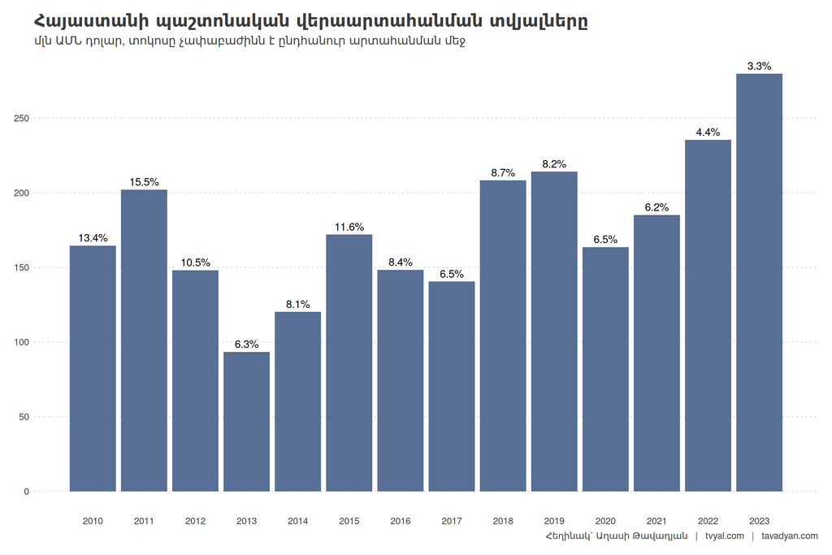

**Գծապատկեր 2.**

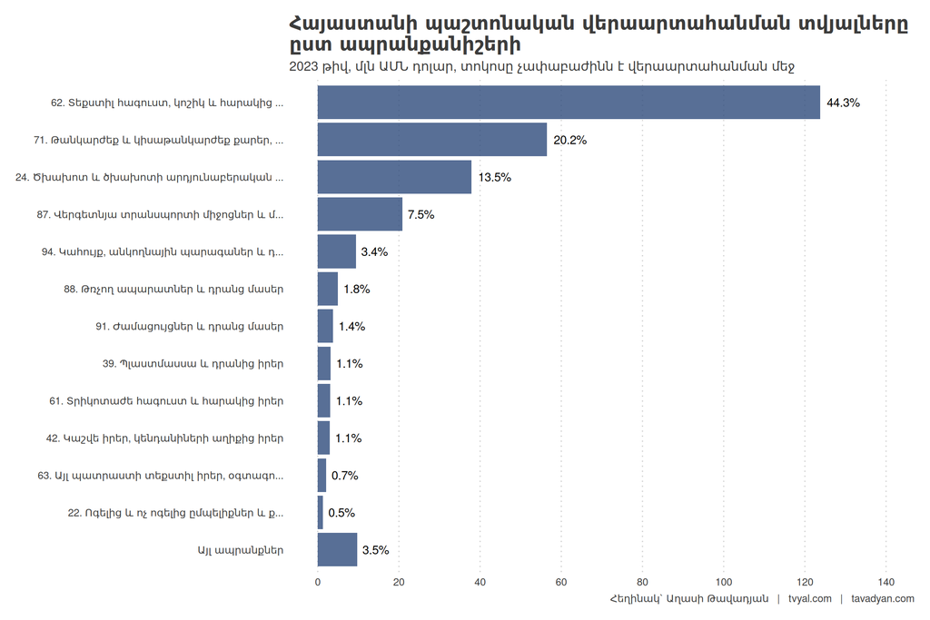

Նշենք, որ 2022 և 2023 թվականի արտահանման և ներմուծման կառուցվածքում զգալի փոփոխություններ են տեղի ունեցել, և վերաարտահանման պաշտոնական տվյալները դժվար է դիտարկել որպես իրականությանը համահունչ: Գնահատենք և ներկայացնենք իրական վերաարտահանման ծավալները:

> Ձեզ կարող է հետաքրքրել նաև հետևյալ վերլուծությունը.

> [📈📉❓ Արտահանման 55.3 տոկոս աճ թե՞ -12.2 տոկոս անկում](https://www.tvyal.com/newsletter/2024/2024_02_16)։

### Վերաարտահանման իրական պատկերը Հայաստանում

Երրորդ գծապատկերում ներկայացված է վերաարտահանման գնահատված ցուցանիշները ըստ տարիների։ Նշենք, որ մեր կողմից մշակված վերաարտահանման մեթոդաբանությունը ներկայացված է հաջորդ մասում։

**Գծապատկեր 3.**

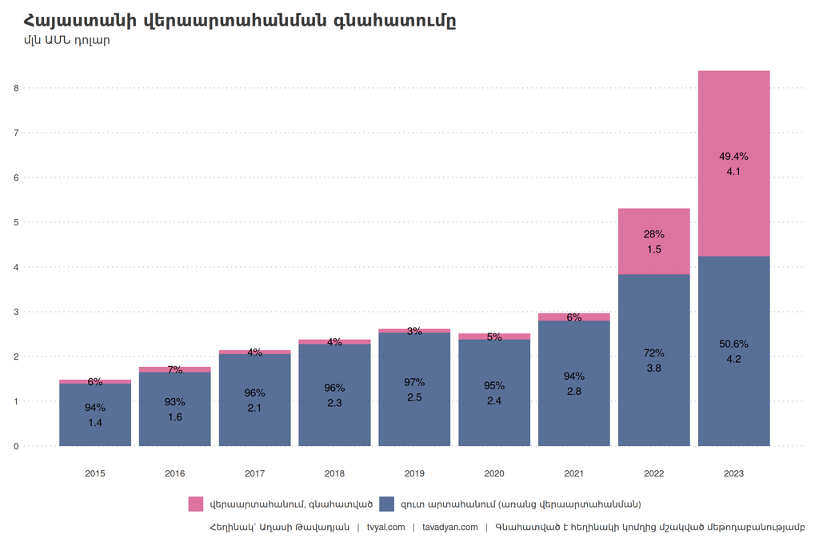

Ինչպես երևում է գծապատկերից, մեր կողմից մշակված մեթոդաբանությամբ 2021 թվականի վերաարտահանումը կազմում էր 5.6% կամ 167 մլն ԱՄՆ դոլար, իսկ 2022 թվականի արտահանման 27.7% կամ 1.47 մլրդ դրամի արտահանումը գնահատվել է որպես վերաարտահանում: Եթե դիտարկենք միայն զուտ արտահանումը, ապա իրական արտահանման աճը 2022 թվականին կազմել է 37%, իսկ վերաարտահանումը աճել է մոտ 9 անգամ։ Հիշեցնենք, որ պաշտոնական արտահանման ցուցանիշը 2022 թվականի ընթացքում աճել է 79.0%: Նշենք, որ նույնիսկ զուտ արտահանումը այս տարի գրանցել է ռեկորդային աճ` համեմատած անցած տարիների հետ: Սա ցույց է տալիս, որ 2022 թվականին արտահանման աճը ապահովվել է ոչ միայն վերաարտահանման հաշվին։

> 2023 թվականի արտահանման **կեսը** վերաարտահանում էր։

2023 թվականին արտահանման կեսը (49.4%) կամ 4.14 մլրդ դոլարը գնահատվել է որպես վերաարտահանում։ Եթե դիտարկենք միայն զուտ արտահանումը, ապա իրական արտահանման աճը 2022 թվականին կազմել է մոտ 10%, համեմատած պաշտոնական արտահանման 55% աճին։ Նշենք, որ 2023 թվականին գնահատված վերաարտահանումը աճել է 2.8 անգամ (1.5 մլրդ դոլարից 4.1 մլրդ դոլար)։

**Գծապատկեր 4.**

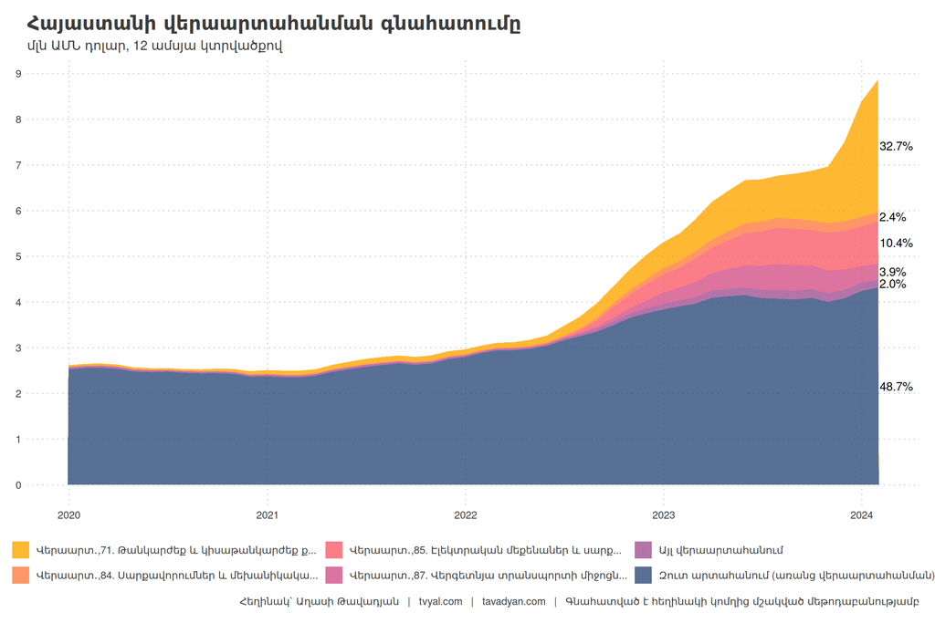

Ինչպես երևում է վերջին գծապատկերից, թանկարժեք քարերն ու մետաղները (ԱՏԳ ԱԱ 71)՝ հիմնականում ոսկու արտահանումը, դարձել են արտահանման գերակշռող ճյուղ՝ ընդհանուր արտահանման մոտ 1/3-ը կազմել է թանկարժեք քարերի և մետաղների վերաարտահանումը։ Ոսկու վերաարտահնման սրընթաց աճը սկսվել է 2023 թվականի նոյեմբերից և դեռ շարունակվում է։ Վերաարտահանման մեջ 2/3 մասը զբաղեցնում է այս ապրանքատեսակի վերաարտահանումը։ Նշենք նաև, որ 2024 թվականի հունվարի դրությամբ նախորդ 12 ամիսների վերաարտահանումը կազմում է ընդհանուր արտահանման 51,3 տոկոսը։

> Եթե ուզում եք իմանալ, թե ինչու է ոսկու վերաարտահանումը դարձել տնտեսական ակտիվության աճի հիմնապատճառ, ապա կարդացեք հետևյալ վերլուծությունը.

> [🌿🤨💎 Թանկարժեք էֆեկտ․ 2024 թվականի տնտեսական աճի պատճառները](https://www.tvyal.com/newsletter/2024/2024_03_29)։

### Վերաարտահանման ճշգրիտ գնահատման մեթոդաբանության մշակում

Վերաարտահանման տվյալները ճշգրիտ հաշվարկելու համար օգտագործվել է հետևյալ մեթոդաբանությունը: Ամսական կտրվածքով դիտարկվել են արտաքին տնտեսական գործունեության ապրանքային անվանացանկի (ԱՏԳ ԱԱ) վեցանիշ ծածկագրերը կամ ենթավերնագրերը: Նշենք, որ ավելի ճշգրիտ հաշվարկներ կատարելու համար նպատակահարմար է օգտագործել ԱՏԳ ԱԱ տասանիշ ծածկագրերը, սակայն դրանք ստանդարտացված չեն և յուրահատուկ են յուրաքանչյուր երկրի համար, ինչպես նաև այդ տվյալները հասանելի չեն:

Երկրորդ խմբի ապրանքների մեջ են մտնում մետաղաձուլության և ծանր արդյունաբերության ապրանքները: Այս ապրանքների խումբը կարելի է հստակ մեթոդաբանությամբ որոշել վերաարտահանման իրական չափաբաժինը, քանի որ այս ապրանքային խմբի մեջ կա՛մ արտահանումը համազոր չէ ներմուծմանը, կա՛մ էլ Հայաստանը դեռ չունի այդ հզորությունները որպեսզի արտադրի բարձր տեխնոտարություն ունեցող ապրանքներ: Օրինակի համար` Հայաստանը 2022 թվականին արտահանել է 173,0 մլն դոլարի երկաթ և պողպատ (ԱՏԳ ԱԱ 72, արտահանման 3.3%) և ներմուծել է 7.8 մլն դոլարի երկաթ և պողպատ: Քանի որ արտահանումը և ներմուծումը համազոր չեն, և արտահանումը մի քանի անգամ գերազանցում է ներմուծմանը, սա չի կարող համարվել վերաարտահանում: Այս խմբի մեջ են նաև մտնում այն ապրանքները, որոնք պահանջում են բարձր տեխնոլոգիական հագեցվածության աստիճան, որոնցից է օրինակի համար ԱՏԳ ԱԱ 85 ծածկագիրը, որի մեջ մտնում է կենցաղային տեխնիկան: 2021թ. Հայաստան ներմուծվել է 382.2 մլն դոլարի կենցաղային տեխնիկա (ներմուծման 7.2%) և արտահանվել է 24.9 մլն դոլարի կենցաղային տեխնիկա (արտահանման 0.8%), իսկ 2022թ. ներմուծվել է 865.0 մլն դոլարի (ներմուծման 10.0%, 2.3 անգամ աճ) և արտահանվել է 507.1 մլն դոլարի կենցաղային տեխնիկա (արտահանման 9.6%, 20 անգամ աճ): Հայաստանում դեռ առկա չեն կենցաղային տեխնիկա արտադրող գործարաններ, և հասկանալի է, որ այս ծածկագրի արտահանումը ամենայն հավանականությամբ վերաարտահանում է, որի ծավալները պետք է գնահատվեն: Նույն իրադրությունն է 87 տրանսպորտային միջոցների արտահանման հետ, որի արտահանումը 2022թ. անսպասելիորեն աճեց ավելի քան 20 անգամ:

Նշենք, որ ապրանքների վերաարտահանումը գնահատվել է ըստ հետևյալ հինգ առևտրային գործընկեր տարածաշրջաններ` ԵԱՏՄ, ԵՄ, Միջին Արևելք, Մեծ Չինաստան (որի մեջ մտնում է Հոնկոնգը) և այլ պետություններ: Ստորև ներկայացված է արտահանման տեսակարար կշիռը ըստ տարիների այս տարածաշրջանների համար:

**Գծապատկեր 5.**

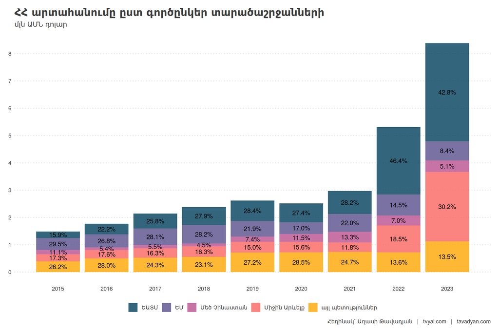

**Նշենք, որ սա առաջին հետազոտությունն է վերաարտահանման ուսումնասիրության շարքում: Սպասեք այս հետազոտության շարունակությանը հաջորդ շաբաթների ընթացքում։**

## PODCAST !!

### Խոսենք թվերով #3

[Դրամի դրաման. Ինչի՞ց է կախված դրամ/դոլար փոխարժեքը և ինչպես կփոփոխվի առաջիկայում](https://www.youtube.com/watch?v=4PPzVKfwUko)

- 🔘 Ի՞նչ գործոններից է կախված հայկական դրամի արժեքը
- 🔘 Ի՞նչ փուլեր է ունեցել դրամ-դոլար փոխարժեքը վերջին տասնամյակներին
- 🔘 Ի՞նչ դասեր քաղել անցյալի փորձից
- 🔘 Ինչպե՞ս կփոխվի դոլարի փոխարժեքը առաջիկայում

How2B-ում «խոսում ենք թվերով»՝ տնտեսագետ Աղասի Թավադյանի հետ:

Թեմայով վերլուծությունը ներկայացված է tvyal.com կայքում՝ [💵🪙🎭 Դրամի դրամա․ Ինչո՞ւ է արժեզրկվում և արժևորվում դրամը](https://www.tvyal.com/newsletter/2024/2024_04_05)

[figure not shown]

## English Summary

### 🚀♻️🟨 Gold rush. Half of Armenia’s exports are re-exports

This week the newsletter delves deep into the intricacies of Armenia’s export landscape, shedding light on a pivotal discovery: by their estimations, half of Armenia’s exports are identified as re-exports. This revelation unveils a fundamental aspect of the country’s economic activity, showcasing a substantial reliance on re-exporting goods. Such a revelation not only underscores the evolving nature of Armenia’s trade dynamics but also hints at the intricate interplay between domestic production and international trade, reshaping the narrative surrounding the country’s economic prowess on the global stage.

Furthermore, the analysis presented in the newsletter underscores the importance of accurately assessing re-export data to grasp the true extent of Armenia’s economic activities. Through meticulous methodology development, the newsletter offers insights into the complexities involved in distinguishing between pure exports and re-exports, especially within industries where Armenia holds production capabilities. This comprehensive examination not only provides clarity on Armenia’s export patterns but also sets the stage for further research into the nuanced dynamics of re-export-driven economies in the region and beyond.

Այս վերլուծությունը առկա է նաև [մեր կայքէջում](https://www.tvyal.com/newsletter/2024/2024_04_12), այս վերլուծության կոդը և տվյալները դրված են նաև [Github-ում](https://github.com/tavad/tvyal_newsletter)։

Եթե հնարավոր է, խնդրում եմ այս նյութը ուղարկել նաև այն մարդկանց, ում այն կարծում եք կարող է հետաքրքրել:

Սպասեք հաջորդ հաղորդագրությանը հաջորդ ուրբաթ օրը:

Հարգանքներով,  
Աղասի Թավադյան  
12.04.2024  
[tvyal.com](https://www.tvyal.com/)  
[tavadyan.com](https://www.tavadyan.com/)

[Was this email forwarded to you? Subscribe here.](https://www.tvyal.com/subscribe)

[Բաժանորդագրվեք](https://www.tvyal.com/subscribe)

**Ուշադրություն. Ձեր էլ.փոստը մեյլիսթի մեջ է, որի միջոցով ես կիսվում եմ շաբաթական նյութեր, որոնք հիմնականում ներկայացնում են Հայաստանի տնտեսությանը: Նյութերը ներառում են գծապատկերներ, [տվյալների բազաներ](https://github.com/tavad/tvyal_newsletter), տեսանյութեր, հոդվածներ, [առցանց վահանակներ](https://www.tvyal.com/projects), տնտեսական գործիքներ, կանխատեսումներ և հաշվետվություններ: Եթե ցանկանում եք չեղարկել բաժանորդագրությունը, խնդրում եմ տեղեկացրեք ինձ, և ես կհեռացնեմ ձեր էլ. փոստը ցուցակից: Գրեք նաև եթե ունեք մենկնաբանություններ:**

**Important! Your email is part of the mailing list where I share weekly materials primarily focused on the Armenian economy. These materials encompass charts, [databases](https://github.com/tavad/tvyal_newsletter), videos, articles, [online dashboards](https://www.tvyal.com/projects), economic tools, forecasts, and reports. If you wish to unsubscribe, please let me know, and I will remove your email from the list. Please share your comments as well․**